# PA1_template.Rmd

Nikolas Rohrmann

12/27/2021

## Loading and Preprocessing the data

Here I am using read.csv to load the data in to R. The function complete.cases() removes all rows that include missing values. Also, I am loading a few packages that I am going to need later.

```r
library(dplyr)
```

```r
library(plotly)
library(ggplot2)

data <- read.csv(file="/Users/okc_rapid/Desktop/R/course-project-getting-and-cleaning-data/activity.csv")
data <- data[complete.cases(data),]
```

## What is the mean total number of steps taken per day?

Harnessing aggregate() I can calculate the total amount of steps taken per day and put that into a histogram. Setting breaks for to ten allows for a more clear image of the distribution. As you can see, the person that collected the most frequently makes between about 8,000 to 16,000 steps. On average she completes 10766,19 steps per day. The median is not that different with about 10765 steps.

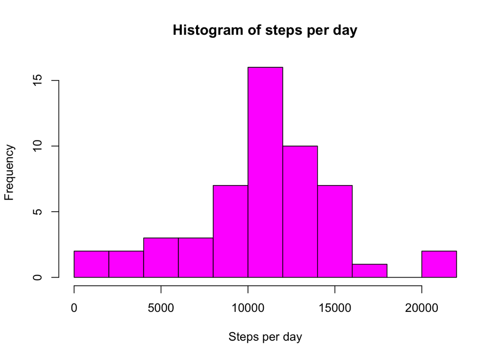

```r
stepsDay <- aggregate(data[,1], by = list(data[,2]), FUN = sum)

hist(stepsDay$x, xlab = "Steps per day", main = "Histogram of steps per day", border = "black", col = "magenta", breaks = 10)
```

```r
mean(stepsDay$x)
```

```
## [1] 10766.19
```

```r
median(stepsDay$x)
```

```
## [1] 10765
```

## What is the average daily activity pattern?

This time we were supposed to create a time series plot that shows the average amount of steps taken per interval. You can see my version of the blot below. Again, I used the aggregate function to calculate the average number of steps per interval. The last command in this code chunk is desigend to get the interval with the maximum amount of steps. It is the interval from 835 to 839.

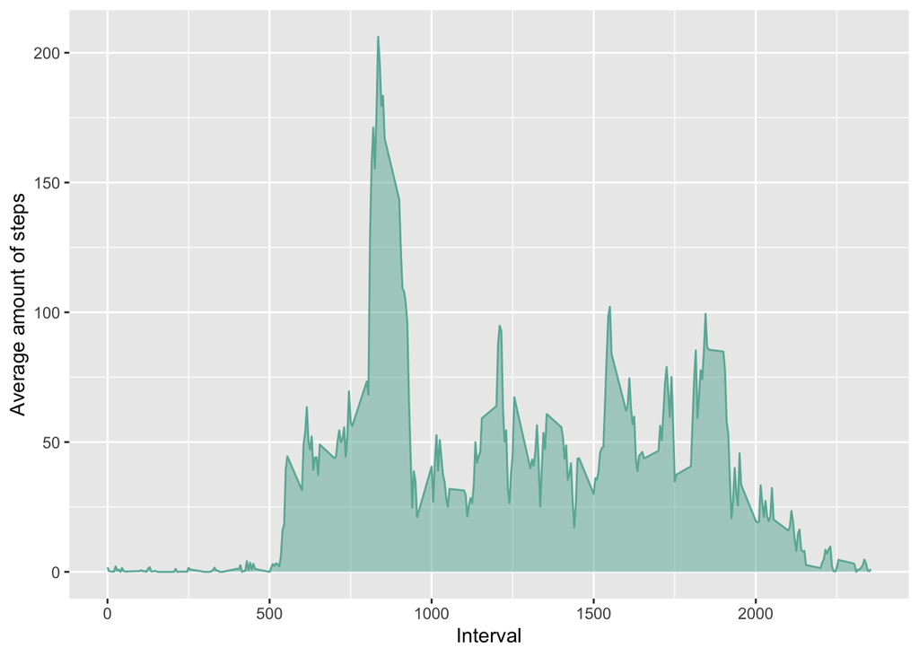

```r
stepsInterval <- aggregate(data[,1], by = list(data[,3]), FUN = mean)

p <- stepsInterval %>% ggplot(aes(x= Group.1, y= x)) + geom_area(fill="#69b3a2", alpha=0.5) + geom_line(color="#69b3a2") +ylab("Average amount of steps") + xlab("Interval")

p
```

```r
stepsInterval[which.max(stepsInterval$x),]
```

```
##     Group.1        x
## 104     835 206.1698
```

## Imputing Missing Values

Here I am first reading in the data for a second time, because I removed the missing values entirely from my original dataset.

As required, I calculate the number of rows that contain a missing value of steps in the second row: 2304.

Row 3 is supposed to remind us, how I calculated the means per interval, which I am going to use to impute the missing values. The for and embedded if loop replace each missing value with the mean for that specific interval. We were supposed to put that into a new dataset, which is not really necessary, but I complied by saving the dataset as data3.

stepsDay2 is the total of steps per day, but with the imputed values. The two histograms don’t look to different and so do the mean and median. The difference between the original and the new mean is 0. Only the median has changed slightly.

```r
data2 <- read.csv(file = "/Users/okc_rapid/Desktop/R/course-project-getting-and-cleaning-data/activity.csv")

sum(is.na(data2$steps))
```

```
## [1] 2304
```

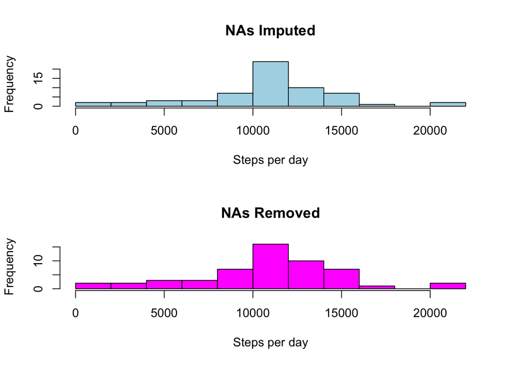

```r
stepsInterval <- aggregate(data[,1], by = list(data[,3]), FUN = mean)

for (i in 1:length(data2$steps)){

  if(is.na(data2[i,1]) == TRUE){

    y <- data2[i,3]
    data2[i,1] <- stepsInterval[stepsInterval$Group.1 == y, 2]
  }
  i <- i + 1
}

data3 <- data2

stepsDay2 <- aggregate(data3[,1], by = list(data3[,2]), FUN = sum)

par(mfrow = c(2,1))
hist(stepsDay2$x, xlab = "Steps per day", main = "NAs Imputed", border = "black", col = "lightblue", breaks = 10)
hist(stepsDay$x, xlab = "Steps per day", main = "NAs Removed", border = "black", col = "magenta", breaks = 10)
```

```r
mean(stepsDay$x) - mean(stepsDay2$x)
```

```
## [1] 0
```

```r
median(stepsDay$x) - median(stepsDay2 $x)
```

```
## [1] -1.188679
```

## Are there differences in activity patterns between weekdays and weekends?

Using the dplyr package’s mutate function I can add a column that contains the specific weekday as a factor. However, I needed to rename the levels, because the weekdays function yields the actual weekday (Monday, Tuesday etc.). After that, I used the aggregate function again, but this time with two factors inweek and interval.

Then, I used the split function to create two independent data frames. The rest is just for creating the respective time series plots. The plots reveal major differences in activity. On weekdays, the person only is particularly active in the morning (before 1000). Whereas on weekends, she has an extended period of activity from about 750 t0 2050. Also, it seems like in total she is moving a lot more on weekends than on weekdays.

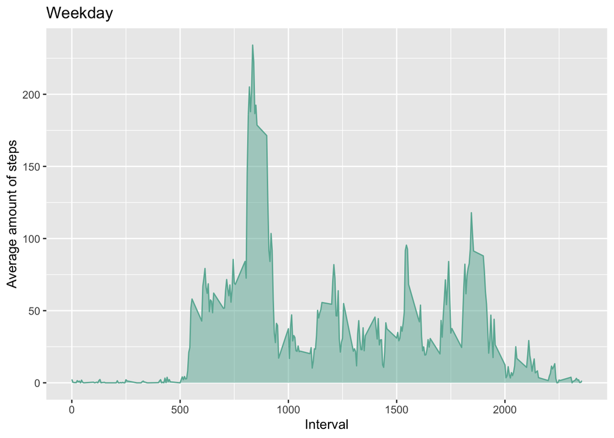

```r
data$date <- as.Date(data$date)
dataWeek <- mutate(data, inweek = factor(weekdays(data$date)))
levels(dataWeek$inweek) <- c("weekday", "weekday", "weekday", "weekday", "weekday", "weekend", "weekend")

stepsIntervalWeek <- aggregate(dataWeek[,1], by = list(dataWeek$interval, dataWeek$inweek), FUN = mean)

d <- split(stepsIntervalWeek, stepsIntervalWeek$Group.2)

weekday <- d[1]
weekend <- d[2]

weekday <- as.data.frame(weekday)
weekend <- as.data.frame(weekend)

par(mfrow = c(2,1))

g <- weekday %>% ggplot(aes(x= weekday.Group.1, y= weekday.x)) + geom_area(fill="#69b3a2", alpha=0.5) + geom_line(color="#69b3a2") +ylab("Average amount of steps") + xlab("Interval") + ggtitle("Weekday")

g
```

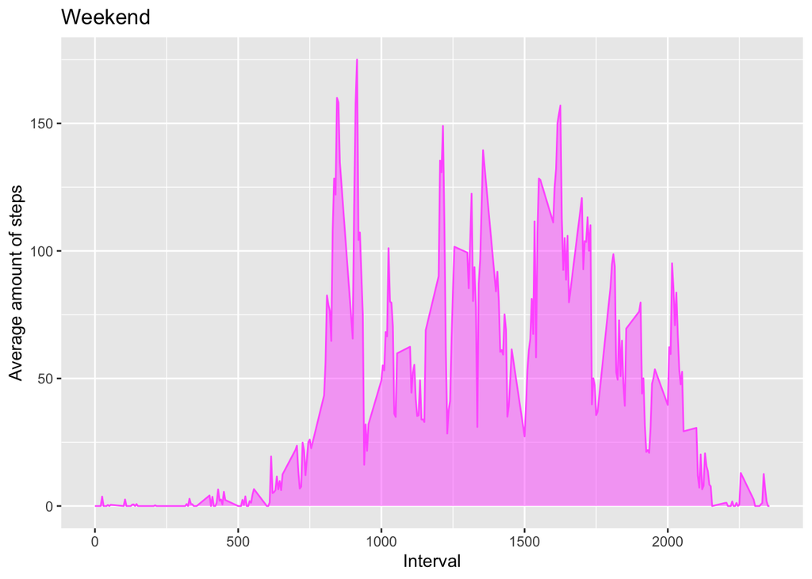

```r
h <- weekend %>% ggplot(aes(x= weekend.Group.1, y= weekend.x)) + geom_area(fill="#ff66ff", alpha=0.5) + geom_line(color="#ff66ff") +ylab("Average amount of steps") + xlab("Interval") + ggtitle("Weekend")

h
```